# clustering sars-cov-2

# Preparing data

```r
gisaidall <- as.phyDat(gisaidall)
```

Now extract the date and compute a matrix of time differences, then convert it to a dist.

```r
dt <- meta_fig$date
dt <- ymd(dt)
t.diff <- sapply(as.list(dt),function(x){return(abs(x-dt))})
t.diff <- as.dist(t.diff)
```

Now we compute hamming distances. Putting `ratio=FALSE` ensures we get the actual hamming distance and not a normalized version.

```r
tmp <- dist.hamming(gisaidall,ratio=FALSE)
#tmp<-dist.ml(gisaidall)
```

This code would normalize by difference in time if you uncomment it, but right now we don’t do this.

```r
# add 1 to avoid division by zero
#gen.d <- tmp/(t.diff+1)
gen.d <- tmp
```

In the next chunk here, I manually assign the different countries to continents.

```r
# for now a hack to make everything work out right
# when we do this for the USA only
if (us.only) {
  meta_fig$region <- meta_fig$division
}
locs <- meta_fig$region
```

Now we create a set of colors to color code the regions.

```r
colors_list <- unique(locs)
new <- data.frame(colors=colors_list,num=seq(1,length(colors_list)))
samps_col<-rep(1,length(locs))
for (j in 1:nrow(new)){
  samps_col[locs==new[j,1]]<-new[j,2]
}
```

# Clustering

Let’s now try a variety of clustering algorithms. In general we will be using the pairwise hamming distance as the main input to clustering.

## Multidimensional scaling

First we see how mds on the distance matrix works.

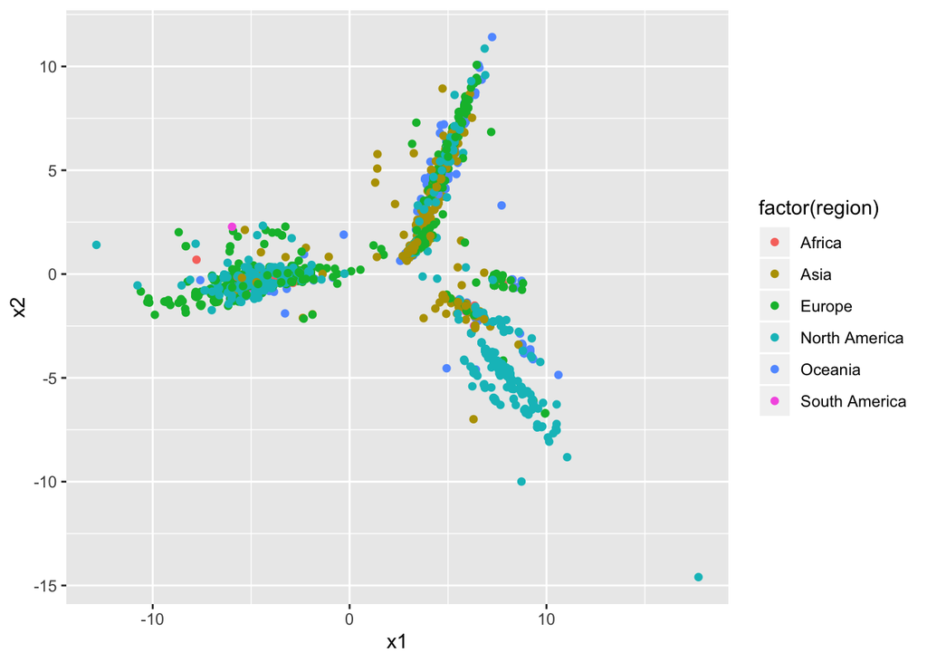

```r
mds_clust <-cmdscale(as.matrix(gen.d),eig=T,k=3)

df.mds <- data.frame(mds_clust$points[,1:2])
names(df.mds) <- c('x1','x2')
df.mds <- df.mds %>% mutate(region=meta_fig$region,strain=meta_fig$strain)

ggplot(df.mds,aes(x=x1,y=x2,col=factor(region))) + geom_point()
```

Just eyeballing this, it seems we could make 4 clusters fairly naturally. However, the clusters are not very well separated by MDS.

## t-SNE

Now we try t-SNE, a reasonably new method for nonlinear embedding of high-dimensional data in a low-dimensional space. This is a very hot method in biology these days.

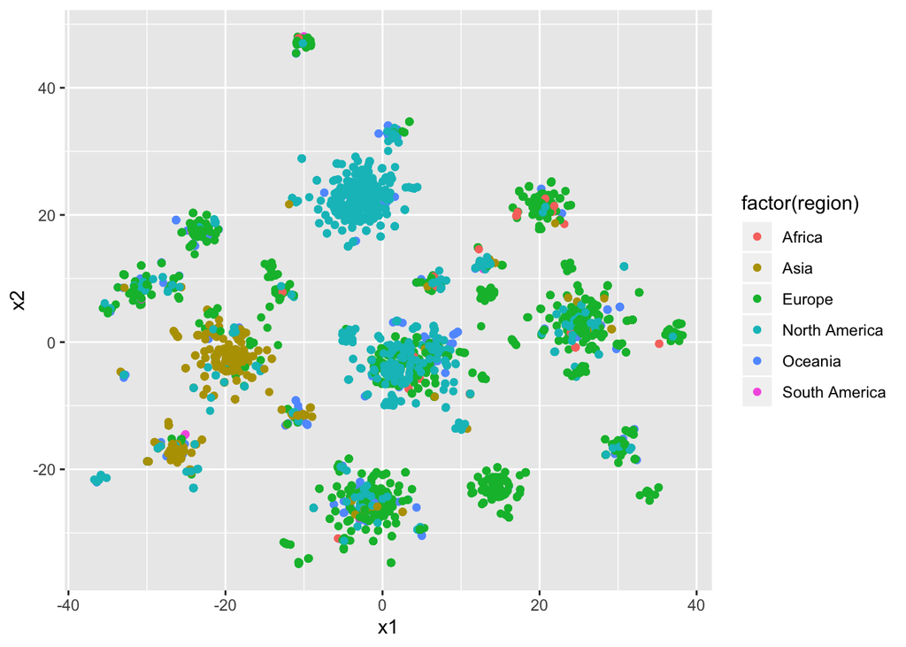

```r
tsne_clust <- Rtsne(as.matrix(gen.d),dims=2,is_distance = TRUE)

df.tsne <- data.frame(tsne_clust$Y)
names(df.tsne) <- c('x1','x2')
df.tsne <- df.tsne %>% mutate(region = meta_fig$region,strain=meta_fig$strain)

ggplot(df.tsne,aes(x=x1,y=x2,col=factor(region))) + geom_point()
```

## Hierarchical agglomerative clustering

Here we do hierarchical clustering.

```r
clust <- hclust(gen.d)
```

We can plot the cluster dendrogram like so.

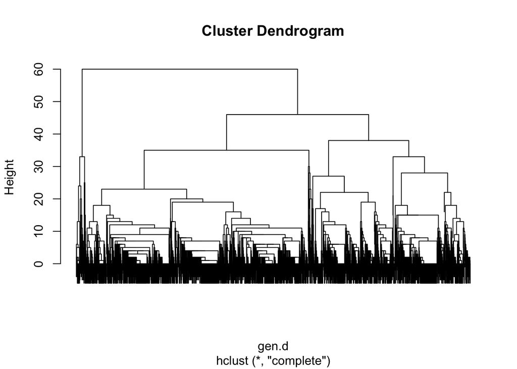

```r
plot(clust,cex=.2)
```

```r
clusts4 <- cutree(clust,k=4)
```

We take the sample IDs to get the countries for the samples in each cluster.

```r
table(meta_fig$region,clusts4)
```

```
##                clusts4
##                    1    2    3    4
##   Africa          40    5    1    0
##   Asia            52  220   84   43
##   Europe        1194  253   98   11
##   North America  370   79  366   10
##   Oceania        170   94   81   24
##   South America   15    8    3    0
```

This gives us some amount of resolution by region. For example, it seems to have one cluster that contains data from Europe and North America but few Asian samples.

```r
n.clusts <- 10
clusts.k <- cutree(clust,k=n.clusts)

table(meta_fig$region,clusts.k)
```

```
##                clusts.k
##                    1    2    3    4    5    6    7    8    9   10
##   Africa          40    5    1    0    0    0    0    0    0    0
##   Asia            43  220   72   11   22    2    1    3    4   21
##   Europe        1179  253   87   11   10   13    0    0    2    1
##   North America  361   79   13  337    8    9   16    0    0    2
##   Oceania        170   94   39   42   24    0    0    0    0    0
##   South America   15    8    1    2    0    0    0    0    0    0
```

```r
#table(dt,clusts.k)
```

We’ve so far ignored time. In the next figure we plot time on the horizontal axis, cluster assignment on the vertical axis, color the points by region, and make the marker sizes proportional to the number of sequences.

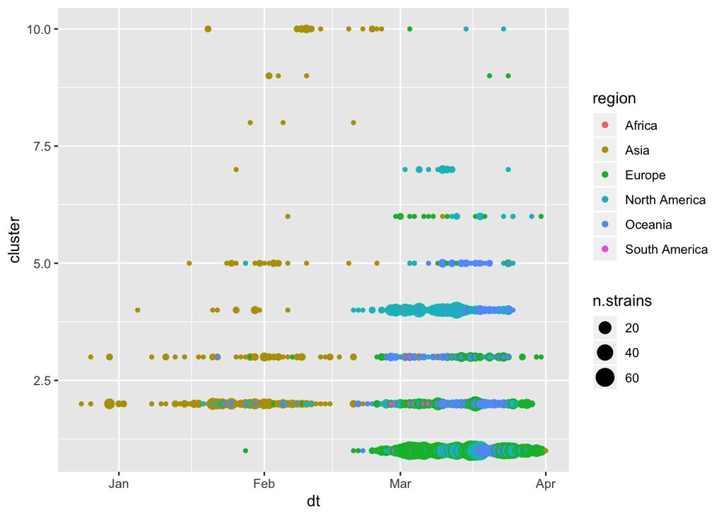

```r
df.clusts.k <- data.frame(cluster = clusts.k,region=meta_fig$region,dt=dt,name=meta_fig$strain)
df.clusts.k.grp <- df.clusts.k %>% group_by(dt,region,cluster) %>% summarize(n.strains=n())

ggplot(df.clusts.k.grp,aes(x=dt,y=cluster,size=n.strains,col=region)) + geom_point()
```

What we see here that is quite useful is that while there are some clusters that are dominated by Europe and North America, for example, the earliest members of most of the clusters were Asian. This suggests that most of the strains in the data existed back in China in January, and the emergence of “European” and “North American” clusters is basically a founder effect.

## Hamming distances by cluster pairs

We compute the distribution of the hamming distance by cluster pairs. The idea here is to see how much lower variation is within than across clusters. The violin plots show the distribution of pairwise distances between each cluster (subplot title) and all other clusters (including itself.)

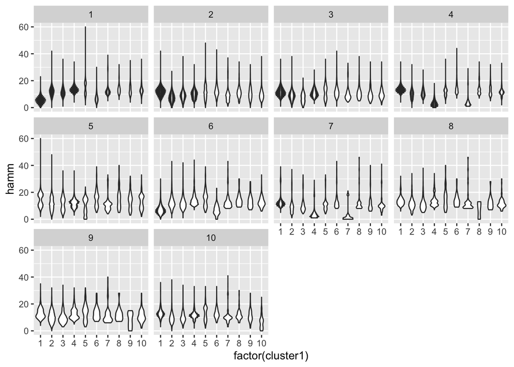

```r
M <- as.matrix(gen.d)
clust.dist <- cbind(rep(clusts.k,each=length(clusts.k)),rep(clusts.k,length(clusts.k)),c(M))
clust.dist <- data.frame(clust.dist)
names(clust.dist) <- c('cluster1','cluster2','hamm')

ggplot(clust.dist,aes(x=factor(cluster1),y=hamm)) + geom_violin() + facet_wrap(~factor(cluster2))
```

# Using location data

Let’s join to the location data and start mapping some things. The idea here is that we’ll replace classifying the data by region with actually plotting on a map. We do a fair amount of tedious work below to obtain the most “granular” location available for each sample.

```r
loc_data <- loc_data[,2:4]
names(loc_data) <- c('location','lat','lon')

meta_fig <- meta_fig %>% left_join(loc_data,by=c("division"="location")) %>% rename(lat_division=lat,lon_division=lon) %>%
            left_join(loc_data,by=c("division_exposure" = "location")) %>% rename(lat_division_exposure=lat,lon_division_exposure=lon) %>% left_join(loc_data,by=c("country" = "location")) %>% rename(lat_country=lat,lon_country=lon)
meta_fig <- meta_fig %>% mutate(best_lat = ifelse(is.na(lat_division_exposure),lat_division,lat_division_exposure)) %>%
                         mutate(best_lon = ifelse(is.na(lon_division_exposure),lon_division,lon_division_exposure)) %>%
                         mutate(best_lat = ifelse(is.na(best_lat),lat_country,best_lat)) %>%
                         mutate(best_lon = ifelse(is.na(best_lon),lon_country,best_lon))

df.clusts.k <- df.clusts.k %>% left_join(meta_fig %>% select(strain,best_lat,best_lon) %>% distinct(),by=c("name"="strain"))
```

Load some packages for making maps. Some of these require you to have things loaded on your system and it can be a bit of an ordeal to get them all working (in particular sf).

```r
pacman::p_load(cowplot, googleway, ggplot2, ggrepel, ggspatial, sf, rnaturalearth, rnaturalearthdata,rgeos,rnaturalearthhires)
```

This obtains a set of polygons that defines a world map.

```r
theme_set(theme_bw())
world <- ne_countries(scale="medium",returnclass="sf")
class(world)
```

```
## [1] "sf"         "data.frame"
```

If you get an error above, run the next line.

```r
#devtools::install_github('ropensci/rnaturalearthhires')
```

Some samples have the same latitude and longitude attached. This collapses the data frame to only unique latitudes and logitudes and the count of the number of samples.

```r
df.clusts.k.summ <- df.clusts.k %>% group_by(cluster,best_lat,best_lon) %>% summarise(n.sample=n())
```

Now we plot the clusters on a world map, with color correpsonding to cluster and size of dot corresponding to number of cases.

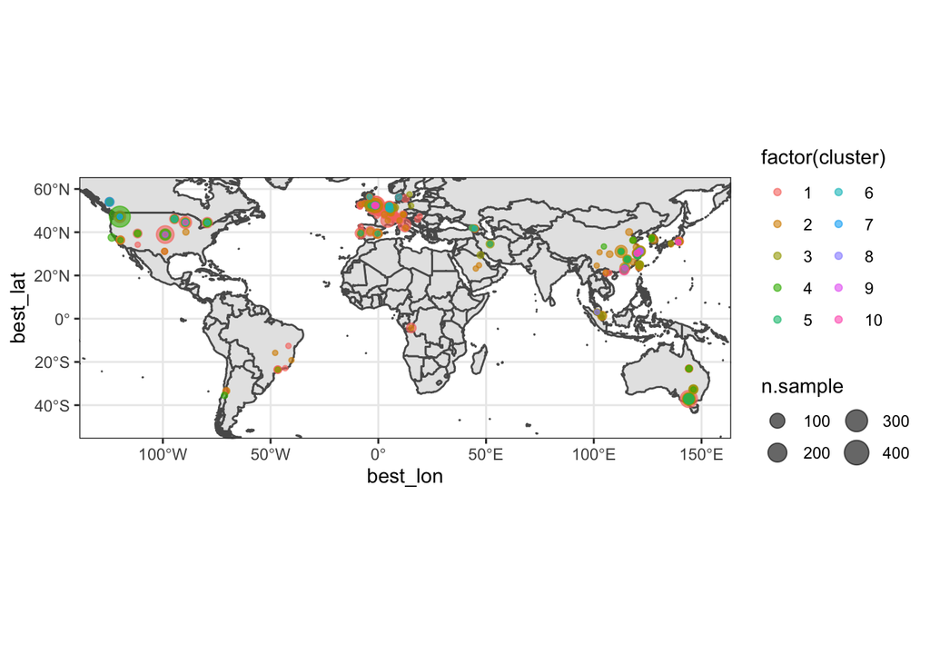

```r
ggplot(data=world) + geom_sf() + geom_point(data=df.clusts.k.summ,aes(x=best_lon,y=best_lat,col=factor(cluster),size=n.sample),alpha=0.6) + ylim(-50,60) + xlim(-125,150) +
  guides(col=guide_legend(ncol=2),size=guide_legend(ncol=2))
```

## An animated timelapse map

Using the animation package, we can make a timelapse version of this map where only the samples collected before a specific date are shown.

```r
pacman::p_load(animation)
```

Note: you may need to install ffmpeg to do this. You can use homebrew to do it on a mac with the command `brew install ffmpeg`

```r
udt <- sort(unique(dt))
for (i in 1:length(udt)) {
  df.clusts.k.summ <- df.clusts.k %>% filter(dt<=udt[i]) %>% group_by(cluster,best_lat,best_lon) %>% summarise(n.sample=n())
  plt1 <- ggplot(data=world) + geom_sf() +
    geom_point(data=df.clusts.k.summ,aes(x=best_lon,y=best_lat,col=factor(cluster),size=n.sample),alpha=0.6) + ylim(-50,60) + xlim(-125,150) + ggtitle(udt[i]) + guides(col=guide_legend(ncol=2),size=guide_legend(ncol=2))
  print(plt1)
}
```

[video not shown]